# MetaGraphs

S. Aguinaga

2/21/2015

## Working Folder

- dsg1:/data/saguinag/MetaGraphs

## Datasets

- DBLP
- IMDB

*DBLP*

*IMDB* Datasets are available at `idmb_data/`

## Data Preparation

- *IMDB* Original (.list) files are parsed into a set of CSV files for movies (titles), actors, and actresses. An inner join results into a data.frame that contains the titles and authors in those movies. From these data.frame vertices and edges output files are created, then concatenated into a single SUBDUE graph format input-file (.g).

## Toy Graph

Selecting 10 lines from our dataset yields 13 vertices. Looking at this toy dataset where AR = Actor, MO = Movie title, and edges are of type “WasIn”:

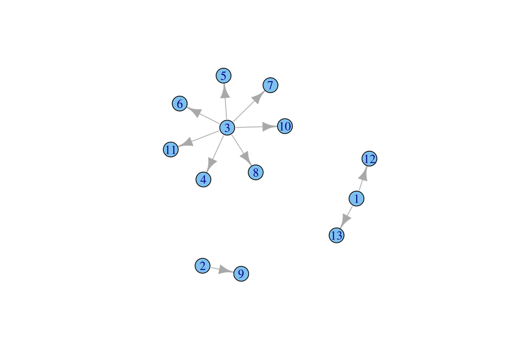

- Vertices and Edges

`v 1 AR` `v 2 AR` `v 3 AR` `v 4 MO` `v 5 MO` `v 6 MO` `v 7 MO` `v 8 MO` `v 9 MO` `v 10 MO` `v 11 MO` `v 12 MO` `v 13 MO` `e 1 12 WasIn` `e 1 13 WasIn` `e 2 9 WasIn` `e 3 4 WasIn` `e 3 5 WasIn` `e 3 6 WasIn` `e 3 7 WasIn` `e 3 8 WasIn` `e 3 10 WasIn` `e 3 11 WasIn`

SUBDUE finds 2 instances of MO<–AR–>MO as the most frequent subgraph (most frequent where nodes don’t repeat). In this case, the structure does repeat where node 3 is the root, see this in th figure.

The best FSG found in this toy example and the embeddings Graph(3v,2e):

| Node | Node | Link |
| --- | --- | --- |
| Edge | Id | Type |
| v | 1 | AR |
| v | 2 | MO |
| v | 3 | MO |
| d | 1 2 | WasIn |
| d | 1 3 | WasIn |